# Coding Assignment 3

Team 6

Due: 2024-12-07 23:59

A Florida health insurance company wants to predict annual claims for individual clients. The company pulls a random sample of 100 customers. The owner wishes to charge an actuarially fair premium to ensure a normal rate of return. The owner collects all of their current customer’s health care expenses from the last year and compares them with what is known about each customer’s plan.

The data on the 100 customers in the sample is as follows:

- Charges: Total medical expenses for a particular insurance plan (in dollars)
- Age: Age of the primary beneficiary
- BMI: Primary beneficiary’s body mass index (kg/m2)
- Female: Primary beneficiary’s birth sex (0 = Male, 1 = Female)
- Children: Number of children covered by health insurance plan (includes other dependents as well)
- Smoker: Indicator if primary beneficiary is a smoker (0 = non-smoker, 1 = smoker)
- Cities: Dummy variables for each city with the default being Sanford

Answer the following questions using complete sentences and attach all output, plots, etc. within this report.

```r
# Bring in the dataset here.

Claims <- read.csv("C:\\UserData\\z002r7kt\\OneDrive - Siemens AG\\Reference Documents\\Learnings\\Fall-24_ECO6416_Group6\\Insurance_Data_Group6.csv")


gt(head(Claims))
```

| Charges | Age | BMI | Female | Children | Smoker | WinterSprings | WinterPark | Oviedo |
| --- | --- | --- | --- | --- | --- | --- | --- | --- |
| 11244.377 | 53 | 26.410 | 0 | 2 | 0 | 1 | 0 | 0 |
| 1256.299 | 19 | 30.400 | 0 | 0 | 0 | 0 | 0 | 1 |
| 4746.344 | 35 | 27.100 | 0 | 1 | 0 | 0 | 0 | 1 |
| 11658.115 | 56 | 28.595 | 1 | 0 | 0 | 1 | 0 | 0 |
| 40273.645 | 41 | 35.750 | 0 | 1 | 1 | 0 | 1 | 0 |
| 14901.517 | 64 | 39.330 | 1 | 0 | 0 | 1 | 0 | 0 |

## Question 1

Randomly select 30 observations from the sample and exclude from all modeling. Provide the summary statistics (min, max, std, mean, median) of the quantitative variables for the 70 observations.

```r
set.seed(123456)
index <- sample(seq_len(nrow(Claims)), size = 30)

train <- Claims[-index,]
test <- Claims[index,]

quant_train <- train %>%
  select(Charges, Age, BMI, Children)

#quant_train %>%
#tbl_summary(statistic = list(all_continuous() ~ c("{mean} ({sd})",
#"{median} ({p25}, {p75})",
#"{min}, {max}"),
#all_categorical() ~ "{n} / {N} ({p}%)"),
#type = all_continuous() ~ "continuous2"
```

## Question 2

Provide the correlation between all quantitative variables

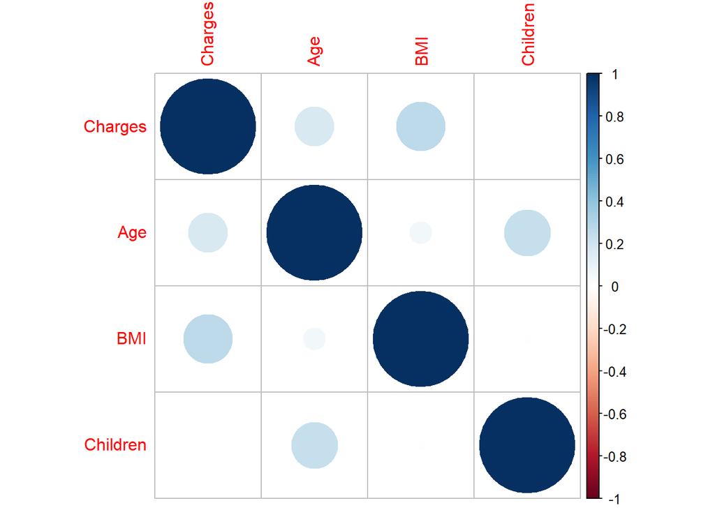

```r
corrplot(cor(quant_train))
```

The correlation matrix shows weak positive relationships between **Charges** and both **Age 0.17** and **BMI 0.26**, while **Charges** has no meaningful correlation with **Children -0.002**. Among the predictors, correlations are generally negligible, with the strongest being between **Age** and **Children 0.23**. There is no indication of strong multicollinearity.

## Question 3

Run a regression that includes all independent variables in the data table. Does the model above violate any of the Gauss-Markov assumptions? If so, what are they and what is the solution for correcting?

```r
original_model <- lm(Charges ~. , data = train[,c(1:9)])
summary(original_model)
```

```
##
## Call:
## lm(formula = Charges ~ ., data = train[, c(1:9)])
##
## Residuals:
##      Min       1Q   Median       3Q      Max
## -11730.5  -2078.7    383.8   2225.9  14810.8
##
## Coefficients:
##                Estimate Std. Error t value Pr(>|t|)
## (Intercept)   -15952.99    3783.69  -4.216 8.36e-05 ***
## Age              278.01      47.37   5.869 1.94e-07 ***
## BMI              454.29     109.40   4.153 0.000104 ***
## Female          -886.89    1280.58  -0.693 0.491208
## Children        -392.27     539.99  -0.726 0.470346
## Smoker         26982.23    1442.33  18.707  < 2e-16 ***
## WinterSprings   -101.07    1839.82  -0.055 0.956370
## WinterPark     -2513.45    1810.95  -1.388 0.170211
## Oviedo          -463.52    1863.34  -0.249 0.804384
## ---
## Signif. codes:  0 '***' 0.001 '**' 0.01 '*' 0.05 '.' 0.1 ' ' 1
##
## Residual standard error: 5211 on 61 degrees of freedom
## Multiple R-squared:  0.8683, Adjusted R-squared:  0.851
## F-statistic: 50.25 on 8 and 61 DF,  p-value: < 2.2e-16
```

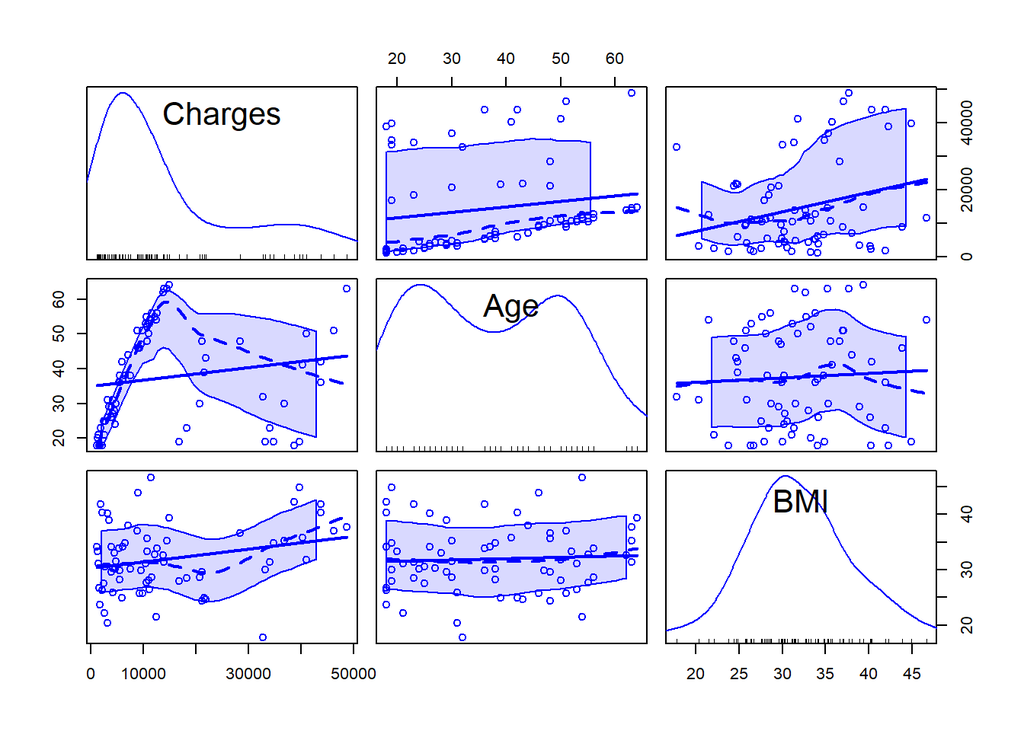

```r
scatterplotMatrix(train[,1:3])
```

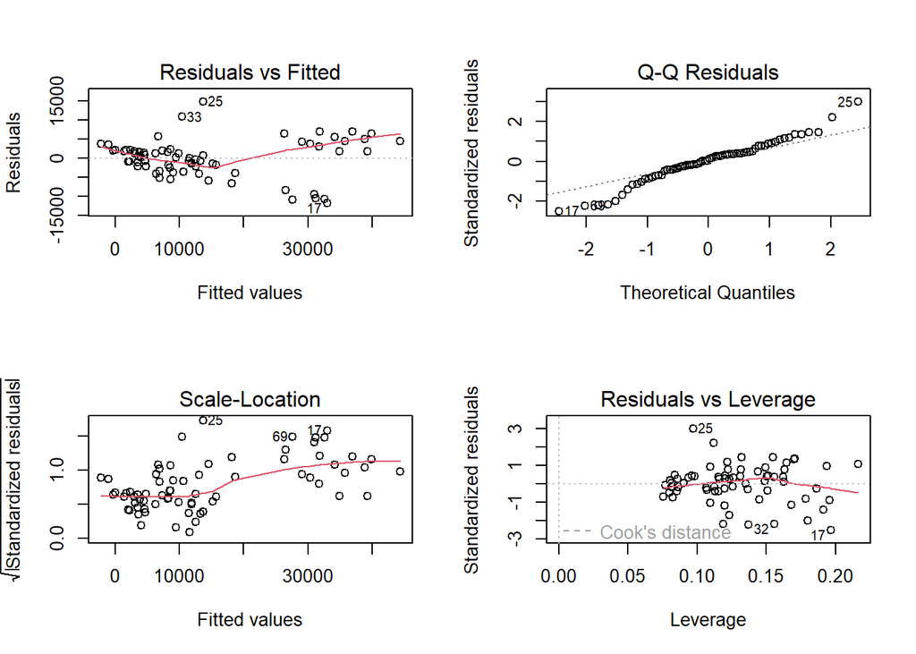

```r
par(mfrow=c(2,2))
plot(original_model)
```

The first plot titled “Residuals vs. Fitted,” shows a non-linear relationship, thus violates a classical assumption.

The second plot titled “Normal Q-Q” would show a 45-degree line upwards. Since that is not the case here the assumption of a normally distributed dependent variable for a fixed set of predictors is violated.

The third plot titled “Scale-Location” does not show some random points around a horizontal line rather has an upward slope indicating heteroscedasticity.

Applying a transformation to the dependent variable Charges (e.g., logarithmic, squared) would solve these issues.

## Question 4

Implement the solutions from question 3, such as data transformation, along with any other changes you wish. Use the sample data and run a new regression. How have the fit measures changed? How have the signs and significance of the coefficients changed?

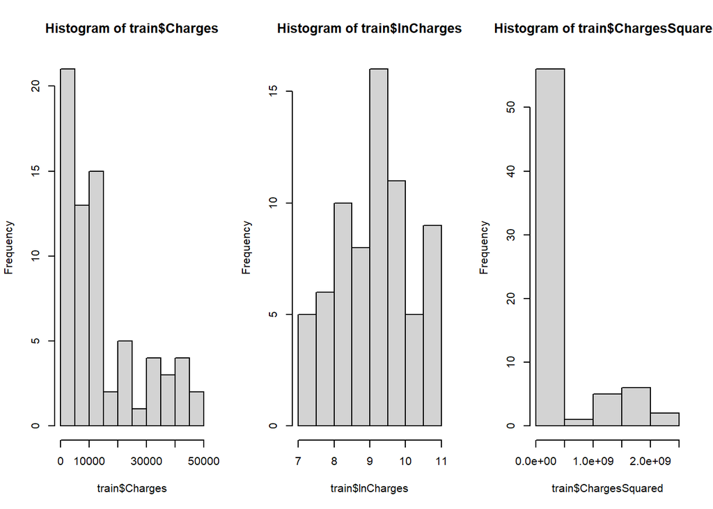

```r
#transform dataset - natural log & squared

#Charges
train$lnCharges <- log(train$Charges)
train$ChargesSquared <- train$Charges^2

#BMI
train$lnBMI <- log(train$BMI)
train$BMISquared <- train$BMI^2

#Age
train$lnAge <- log(train$Age)
train$AgeSquared <- train$Age^2


#Plot Changes - Before and After
#Charges
par(mfrow=c(1,3))
hist(train$Charges) #before
hist(train$lnCharges) #after ln
hist(train$ChargesSquared) #after squared
```

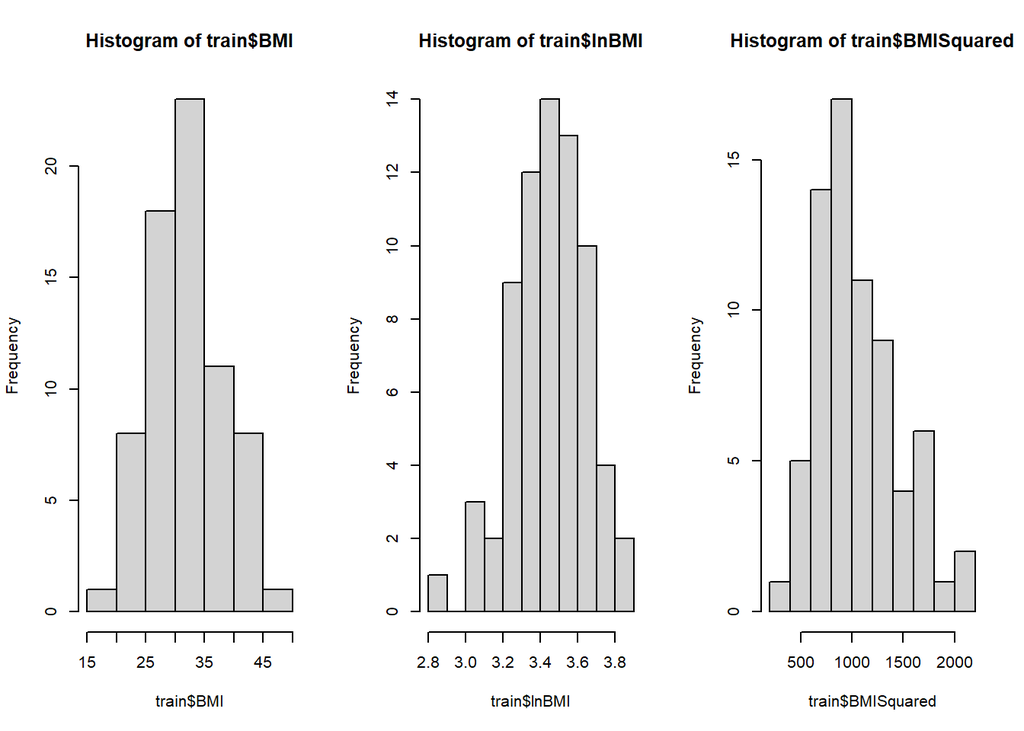

```r
#BMI
par(mfrow=c(1,3))
hist(train$BMI) #before
hist(train$lnBMI) #after ln
hist(train$BMISquared) #after squared
```

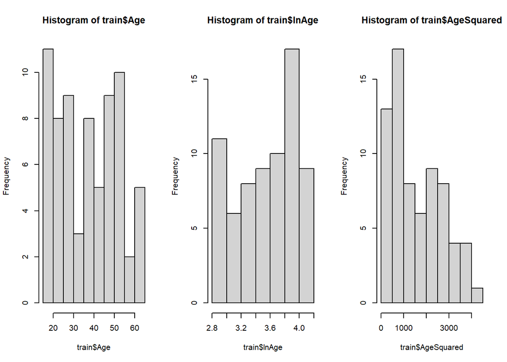

```r
#Age
par(mfrow=c(1,3))
hist(train$Age) #before
hist(train$lnAge) #after ln
hist(train$AgeSquared) #after squared
```

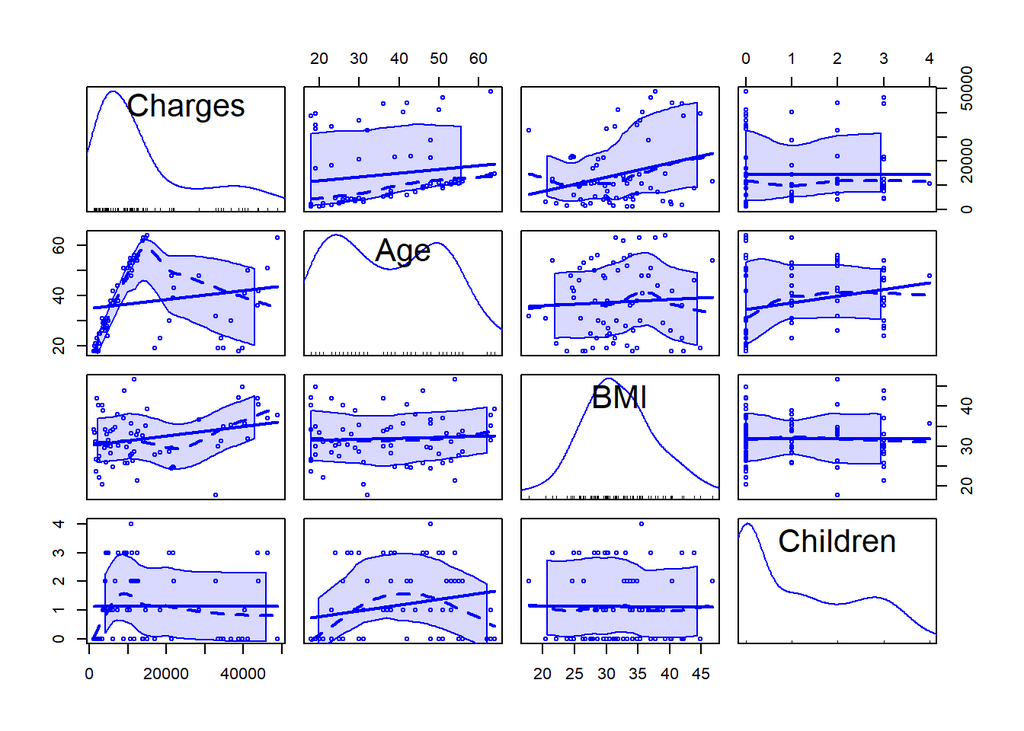

```r
scatterplotMatrix(train[,c(1,2,3,5)]) # grabbing original
```

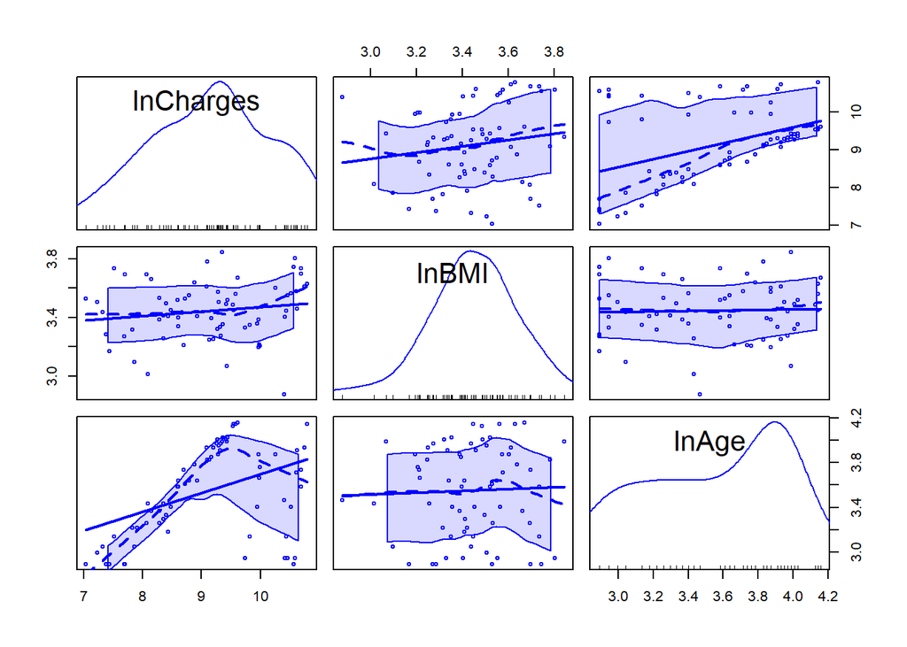

```r
scatterplotMatrix(train[,c(10,12,14)]) # grabbing ln
```

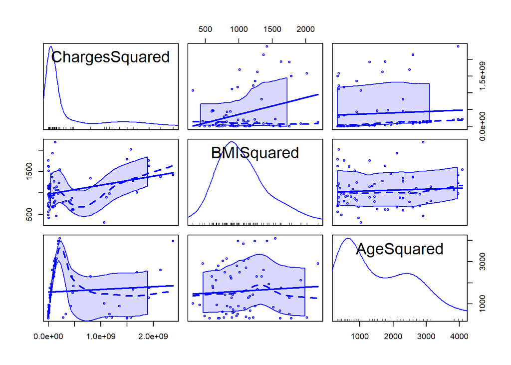

```r
scatterplotMatrix(train[,c(11,13,15)]) # grabbing squared
```

```r
model_log <- lm(lnCharges ~., data = train[,c(4:9,10,12,14)]) #pulling new ln columns
summary(model_log)
```

```
##
## Call:
## lm(formula = lnCharges ~ ., data = train[, c(4:9, 10, 12, 14)])
##
## Residuals:
##      Min       1Q   Median       3Q      Max
## -0.77844 -0.19242  0.00994  0.16611  0.99283
##
## Coefficients:
##               Estimate Std. Error t value Pr(>|t|)
## (Intercept)    1.71480    0.92123   1.861  0.06750 .
## Female         0.04318    0.09502   0.454  0.65116
## Children       0.01159    0.04091   0.283  0.77800
## Smoker         1.87135    0.10683  17.517  < 2e-16 ***
## WinterSprings -0.20177    0.13666  -1.476  0.14496
## WinterPark    -0.28464    0.13398  -2.124  0.03769 *
## Oviedo        -0.05841    0.13834  -0.422  0.67437
## lnBMI          0.69629    0.25244   2.758  0.00766 **
## lnAge          1.29917    0.12520  10.377 4.25e-15 ***
## ---
## Signif. codes:  0 '***' 0.001 '**' 0.01 '*' 0.05 '.' 0.1 ' ' 1
##
## Residual standard error: 0.3871 on 61 degrees of freedom
## Multiple R-squared:  0.8723, Adjusted R-squared:  0.8556
## F-statistic: 52.08 on 8 and 61 DF,  p-value: < 2.2e-16
```

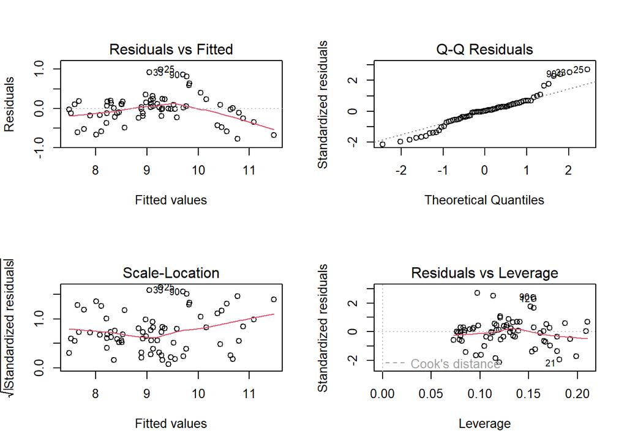

```r
par(mfrow=c(2,2))
plot(model_log)
```

```r
model_quad <- lm(ChargesSquared ~., data = train[,c(4:9,11,13,15)]) #pulling new squared columns
summary(model_quad)
```

```
##
## Call:
## lm(formula = ChargesSquared ~ ., data = train[, c(4:9, 11, 13,
##     15)])
##
## Residuals:
##        Min         1Q     Median         3Q        Max
## -707477282  -99830541   29356429  129227409  777483645
##
## Coefficients:
##                 Estimate Std. Error t value Pr(>|t|)
## (Intercept)   -449932897  134502730  -3.345 0.001411 **
## Female         -59361170   76250964  -0.778 0.439285
## Children       -15495976   31652363  -0.490 0.626196
## Smoker        1146420991   85873774  13.350  < 2e-16 ***
## WinterSprings   79665798  109295957   0.729 0.468852
## WinterPark     -60517937  107723798  -0.562 0.576319
## Oviedo          13607162  110572320   0.123 0.902463
## BMISquared        392716      99374   3.952 0.000204 ***
## AgeSquared        100138      35638   2.810 0.006652 **
## ---
## Signif. codes:  0 '***' 0.001 '**' 0.01 '*' 0.05 '.' 0.1 ' ' 1
##
## Residual standard error: 309300000 on 61 degrees of freedom
## Multiple R-squared:  0.7786, Adjusted R-squared:  0.7495
## F-statistic: 26.81 on 8 and 61 DF,  p-value: < 2.2e-16
```

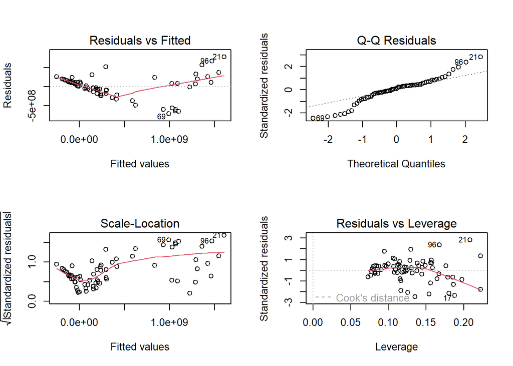

```r
par(mfrow=c(2,2))
plot(model_quad)
```

Comparison of 3 models original_model (not transformed), model_log (log-transformed), and model_quad (squared) revealed that:

The first model **original_model** showed moderate fit **0.851** and a higher Residual Standard Error **5211** compared to the second model. With this model coefficients Age, BMI and Smoker test significant and show a direct relationship with the dependent variable. Other independent variables in the data set did not test significant and show an inverse relationship with the dependent variable.

The second model **model_log** provided the best fit, with the highest Adjusted R-squared **0.856** and the lowest Residual Standard Error **0.387**. With this model coefficients Smoker, lnAge and lnBMI (although reduced) continue to test significant, additionally WinterPark test significant. Signs of the independent variables Female and Children have flipped while others have remained unchanged.

Third model **model_quad** shows non-linear relationships for BMI and Age, its weaker Adjusted R-squared **0.749** and high Residual Standard Error **309000000** indicated poor overall performance. With this model coefficients Smoker, BMISquared,and AgeSquared (although reduced) continues to test significant. Signs of the independent variables WinterSprings and Oviedo have flipped while others have remained unchanged.

Overall the second model **model_log** stood out as the most accurate.

## Question 5

Use the 30 withheld observations and calculate the performance measures for your best two models. Which is the better model? (remember that “better” depends on whether your outlook is short or long run)

```r
test$lnCharges <- log(test$Charges)
test$lnBMI <- log(test$BMI)
test$lnAge <- log(test$Age)

test$original_model_pred <- predict(original_model, newdata = test)
test$model_log_pred <- predict(model_log,newdata = test) %>% exp()


# Finding the error
test$error_om <- test$original_model_pred - test$Charges
test$error_log <- test$model_log_pred - test$Charges

#

#Bias
mean(test$error_om)
```

```
## [1] -1261.521
```

```r
mean(test$error_log)
```

```
## [1] 275.5506
```

```r
#MAE
mae <- function(error_vector){
error_vector %>%
abs() %>%
mean()
}

mae(test$error_om)
```

```
## [1] 2910.693
```

```r
mae(test$error_log)
```

```
## [1] 3766.402
```

```r
#RMSE
rmse <- function(error_vector){
error_vector^2 %>%
mean() %>%
sqrt()
}

rmse(test$error_om)
```

```
## [1] 3942.076
```

```r
rmse(test$error_log)
```

```
## [1] 7267.676
```

```r
#MAPE
mape <- function(error_vector, actual_vector){
(error_vector/actual_vector) %>%
abs() %>%
mean()
}

mape(test$error_om, test$Charges)
```

```
## [1] 0.4644949
```

```r
mape(test$error_log, test$Charges)
```

```
## [1] 0.2444027
```

The second model *model_log* is better for long-term prediction due to its significantly lower MAPE. This suggests it will likely provide more accurate predictions relative to the actual values in terms of percentage error, which is important for long-term forecasts.

## Question 6

Provide interpretations of the coefficients, do the signs make sense? Perform marginal change analysis (thing 2) on the independent variables.

```r
model_log$coefficients["Female"]
```

```
##     Female
## 0.04317663
```

```r
model_log$coefficients["Children"]
```

```
##   Children
## 0.01158525
```

```r
model_log$coefficients["Smoker"]
```

```
##   Smoker
## 1.871352
```

```r
model_log$coefficients["WinterSprings"]
```

```
## WinterSprings
##     -0.201772
```

```r
model_log$coefficients["WinterPark"]
```

```
## WinterPark
## -0.2846438
```

```r
model_log$coefficients["Oviedo"]
```

```
##      Oviedo
## -0.05840776
```

```r
model_log$coefficients["lnBMI"]
```

```
##     lnBMI
## 0.6962885
```

```r
model_log$coefficients["lnAge"]
```

```
##    lnAge
## 1.299173
```

## Question 7

An eager insurance representative comes back with five potential clients. Using the better of the two models selected above, provide the prediction intervals for the five potential clients using the information provided by the insurance rep.

| Customer | Age | BMI | Female | Children | Smoker | City |
| --- | --- | --- | --- | --- | --- | --- |
| 1 | 60 | 22 | 1 | 0 | 0 | Oviedo |
| 2 | 40 | 30 | 0 | 1 | 0 | Sanford |
| 3 | 25 | 25 | 0 | 0 | 1 | Winter Park |
| 4 | 33 | 35 | 1 | 2 | 0 | Winter Springs |
| 5 | 45 | 27 | 1 | 3 | 0 | Oviedo |

```r
new_clients <- data.frame(
  Age = c(60, 40, 25, 33, 45),
  BMI = c(22, 30, 25, 35, 27),
  Female = c(1, 0, 0, 1, 1),
  Children = c(0, 1, 0, 2, 3),
  Smoker = c(0, 0, 1, 0, 0),
  WinterSprings = c(0, 0, 0, 1, 0),
  WinterPark = c(0, 0, 1, 0, 0),
  Oviedo = c(1, 0, 0, 0, 1),
  lnBMI = log(c(22, 30, 25, 35, 27)),
  lnAge = log(c(60, 40, 25, 33, 45)))

  predictions <- predict(
  model_log,
  newdata = new_clients,
  interval = "prediction"
  )

print(predictions)
```

```
##        fit      lwr       upr
## 1 9.171082 8.321615 10.020550
## 2 8.887087 8.085595  9.688578
## 3 9.724645 8.897025 10.552265
## 4 8.597485 7.780221  9.414750
## 5 8.974685 8.143279  9.806091
```

## Question 8

The owner notices that some of the predictions are wider than others, explain why.

## Question 9

Are there any prediction problems that occur with the five potential clients? If so, explain.